# Creating custom functions in R

You are already familiar with functions in R. Every time you use library(), readcsv(), mean(), ggplot(), or other action in R you are calling a function. You can use the power of custom functions to improve your own code. Some advantages of using functions, include:

1. You can reduce the risk of copy/paste errors (e.g., forgetting to update a variable in the pasted code).
2. You can easily document your code and use descriptive names, making it easier for you and others to read your code in the future.
3. If changes are needed, you only have to make the changes to one code block (i.e., the code in the function).
4. You can limit the scope of your variables to only the function.

In general, you should consider creating a function whenever you are copying and pasting a code block that doesn’t require signficant changes.

Let’s take a look at this charting example that doesn’t use custom functions…

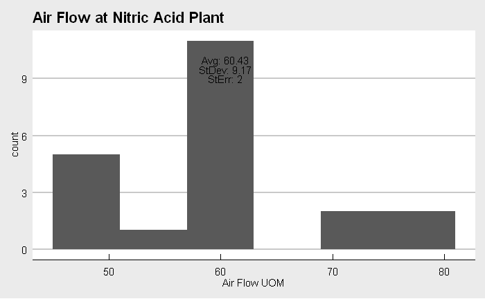

```r
#load libraries
library(tidyverse)
library(ggplot2)
library(ggthemes)
library(datasets) # for this example we'll use the stackloss data
#air flow at nitric acid plant
#calculate stats for air flow
airflow_avg <- mean(stackloss$Air.Flow)
airflow_sd <- sd(stackloss$Air.Flow)
airflow_se <- airflow_sd/sqrt(length(stackloss$Air.Flow))
#plot a histogram of air flow w/ select stats in text boxes
airflow_hist <- ggplot(data = stackloss, mapping = aes(stackloss$Air.Flow)) +
    geom_histogram(bins=6) +
    xlab("Air Flow UOM") +
    ggtitle("Air Flow at Nitric Acid Plant") +
    annotate("text", x=airflow_avg, y=10, label= paste("Avg: ", round(airflow_avg, 2), sep="" )) +
    annotate("text", x=airflow_avg, y=9.5, label= paste("StDev: ", round(airflow_sd, 2), sep="" )) +
    annotate("text", x=airflow_avg, y=9, label= paste("StErr: ", round(airflow_se, 2), sep="")) +
    theme_economist_white(gray_bg=TRUE) + scale_colour_economist() +
    theme(legend.position = "none")
airflow_hist
```

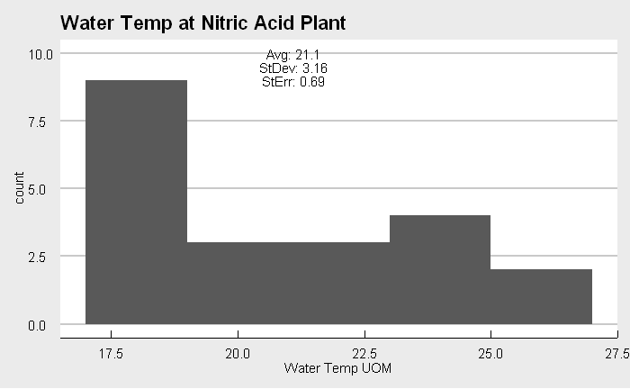

```r
#water temp at nitric acid plant
#calculate stats for water temp
watertemp_avg <- mean(stackloss$Water.Temp)
watertemp_sd <- sd(stackloss$Water.Temp)
watertemp_se <- watertemp_sd/sqrt(length(stackloss$Water.Temp))
#plot a histogram of water temp w/ select stats in text boxes
watertemp_hist <- ggplot(data = stackloss, mapping = aes(stackloss$Water.Temp)) +
    geom_histogram(bins=6) +
    xlab("Water Temp UOM") +
    ggtitle("Water Temp at Nitric Acid Plant") +
    annotate("text", x=watertemp_avg, y=10, label= paste("Avg: ", round(watertemp_avg, 2), sep="" )) +
    annotate("text", x=watertemp_avg, y=9.5, label= paste("StDev: ", round(watertemp_sd, 2), sep="" )) +
    annotate("text", x=watertemp_avg, y=9, label= paste("StErr: ", round(watertemp_se, 2), sep="")) +
    theme_economist_white(gray_bg=TRUE) + scale_colour_economist() +
    theme(legend.position = "none")
watertemp_hist
```

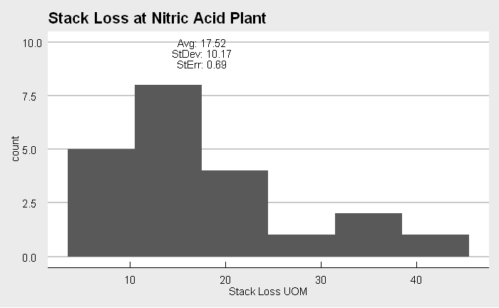

```r
#stack loss at nitric acid plant
#calculate stats for stack loss
stackloss_avg <- mean(stackloss$stack.loss)
stackloss_sd <- sd(stackloss$stack.loss)
stackloss_se <- watertemp_sd/sqrt(length(stackloss$stack.loss))
#plot a histogram of stack loss w/ select stats in text boxes
stackloss_hist <- ggplot(data = stackloss, mapping = aes(stackloss$stack.loss)) +
    geom_histogram(bins=6) +
    xlab("Stack Loss UOM") +
    ggtitle("Stack Loss at Nitric Acid Plant") +
    annotate("text", x=stackloss_avg, y=10, label= paste("Avg: ", round(stackloss_avg, 2), sep="" )) +
    annotate("text", x=stackloss_avg, y=9.5, label= paste("StDev: ", round(stackloss_sd, 2), sep="" )) +
    annotate("text", x=stackloss_avg, y=9, label= paste("StErr: ", round(stackloss_se, 2), sep="")) +
    theme_economist_white(gray_bg=TRUE) + scale_colour_economist() +
    theme(legend.position = "none")
stackloss_hist
```

There’s a lot of replication from copying and pasting. There’s also at least one copy/paste error (the stackloss_se calculation uses the watertemp_sd instead of stackloss_sd). This could be simplified, streamlined, and more accurate with a simple function. Here’s an example (note: you don’t need to reload the libraries but they are included to make it a complete alternative to the above code):

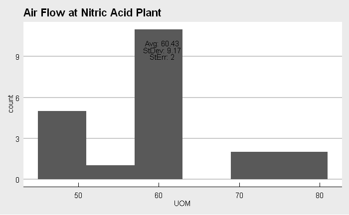

```r
#load libraries
library(tidyverse)
library(ggplot2)
library(ggthemes)
library(datasets) # for this example we'll use the stackloss data
# function to create a histogram plot with summary statistics in text boxes
histogram_statlabels <- function(xdf, xdata, hist_title) {
  #calculate relevant statistics
  xdata_avg <- mean(xdata)
  xdata_sd <- sd(xdata)
  xdata_se <- xdata_sd/sqrt(length(xdata))

  #plot a histogram of data w/ select stats in text boxes
  xdata_hist <- ggplot(data = xdf, mapping = aes(xdata)) +
    geom_histogram(bins=6) +
    xlab("UOM") +
    ggtitle(hist_title) +
    annotate("text", x=xdata_avg, y=10, label= paste("Avg: ", round(xdata_avg, 2), sep="" )) +
    annotate("text", x=xdata_avg, y=9.5, label= paste("StDev: ", round(xdata_sd, 2), sep="" )) +
    annotate("text", x=xdata_avg, y=9, label= paste("StErr: ", round(xdata_se, 2), sep="")) +
    theme_economist_white(gray_bg=TRUE) + scale_colour_economist() +
    theme(legend.position = "none")
  xdata_hist
}
histogram_statlabels(stackloss, stackloss$Air.Flow, "Air Flow at Nitric Acid Plant")
```

The second code example with the function is shorter and easier to read.

Now, let’s assume you want to make some changes. Perhaps you want to move the labels from the position of the average value to the max value, or change the plot theme or colors. In the first example you would have to change every occurence and hope you don’t miss any. In the second example with a function, you only need to make the changes in the function.

If you want to add another histogram for acid concentration, the first example requires you to create another copy of the histogram code and update the relevant values for the acid concentration. In the second example, you simply call the function again:

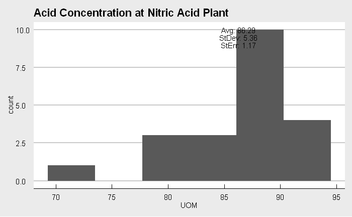

```r
#create acid concentration histogram
histogram_statlabels(stackloss, stackloss$Acid.Conc., "Acid Concentration at Nitric Acid Plant")
```

This is a quick and dirty function, there are ways to streamline it, change fixed values to input parameters (e.g., the number of bins), or break it into several smaller functions. You should design your function based on the time available and cope of the function – is it a solution for a single project or is it something you might want to reuse in future projects. If it’s the latter, you should consider how to make it more generic and create your own library for your functions.

Creating your own functions in R might seem intimidating, but it is quite easy and custom functions can reduce errors, improve consistency, and enhance readability.

For further information, refer to: - [How to write and debug an R function](https://www.r-bloggers.com/how-to-write-and-debug-an-r-function/) by Slawa Rokicki - [Writing Functions in R](https://rpubs.com/williamsurles/292234) by William Surles